# aws-mlflow-in-action

Created by: [Kumar N.P](https://www.linkedin.com/in/kumar-np)

## MLOps using Mlflow

[figure not shown]

### Predicting Heart Disease using Machine Learning

Goal here is to build a machine learning model to predict heart disease and cpature the life-cycle of ML model using Mlflow

#### Machine Learning steps:

- Exploratory data analysis (EDA) - the process of going through a dataset and finding out more about it.
- Model training - create model(s) to learn to predict a target variable based on other variables.
- Model evaluation - evaluating a models predictions using problem-specific evaluation metrics.
- Model comparison - comparing several different models to find the best one.
- Model fine-tuning - once we've found a good model, how can we improve it?
- Feature importance - since we're predicting the presence of heart disease, are there some things which are more important for prediction?
- Cross-validation - if we do build a good model, can we be sure it will work on unseen data?
- Productionizing machine learning models - deploy model in production using MLflow

[figure not shown]

#### 1. Problem Definition

Given clinical parameters about a patient, can we predict whether or not they have heart disease?  
The problem in this ML project is we will be exploring the binary classification. Using differnet features about a patient to predict whether they have heart disease or not.

#### 2. Data

Interrogate the data for the problem definition. This involves sourcing, defining different parameters and discussing with SMEs and finding out expected outcome  
The data for this project is sourced from the [Cleveland database](https://archive.ics.uci.edu/ml/datasets/heart+Disease) from UCI Machine Learning Repository.  
Attributes and features are also referred to as independent variables and a target variable can be referred to as a dependent variable.  
We use the independent variables to predict our dependent variable. In this experiment, the independent variables are a patients different medical attributes and the dependent variable is whether or not they have heart disease

#### 3. Evaluation

Set the success criteria by defining the evaluation metric at the start of a project.  
Since machine learning is very experimental, with the help of SME you might set go nogo as below:

```
If we can reach 85% accuracy at predicting whether or not a patient has heart disease during the proof of concept, we'll pursure this project.
```

This provides a rough goal for a machine learning engineer or data scientist to work towards.  
However, its important to note that the evaluation metric may change over time due to changes in data and introduction new medicines and treatments.

#### Preparing the tools

The libraries will differ from project to project. Below are the list used in this project.

- pandas for data analysis
- NumPy for numerical operations
- Matplotlib/seaborn for plotting or data visualization.
- Scikit-Learn for machine learning modelling and evaluation.
- MLflow to track ML models.

```python
# Regular EDA and plotting libraries
import numpy as np # np is short for numpy
import pandas as pd # pd is short for pandas
import matplotlib.pyplot as plt
import seaborn as sns # seaborn gets shortened to sns

#Display dataframe in table style
from IPython.display import display
from tabulate import tabulate


## Models
from sklearn.linear_model import LogisticRegression
from sklearn.neighbors import KNeighborsClassifier
from sklearn.ensemble import RandomForestClassifier
# Import cross_val_score
from sklearn.model_selection import cross_val_score

## Model evaluators
from sklearn.model_selection import train_test_split, cross_val_score
from sklearn.model_selection import cross_val_predict
from sklearn.model_selection import RandomizedSearchCV, GridSearchCV
from sklearn.metrics import confusion_matrix, classification_report
from sklearn.metrics import precision_score, recall_score, f1_score, accuracy_score
from sklearn.metrics import plot_roc_curve

#Mlflow
import mlflow
import mlflow.sklearn
import mlflow.pyfunc
import mlflow.tensorflow
from mlflow.models.signature import infer_signature

from mlflow.tracking.client import MlflowClient
from mlflow.entities.model_registry.model_version_status import ModelVersionStatus
from mlflow.entities import ViewType
```

```
Starting Spark application
```

```
SparkSession available as 'spark'.
```

### Load Data

Pandas has a built-in function to read .csv files called read_csv() which takes the file pathname of .csv file.

```python
heart_df = pd.read_csv("https://raw.githubusercontent.com/mlops/data/heart-disease.csv") # 'DataFrame' shortened to 'df'
heart_df.shape # (rows, columns)
# convert all int to float to avoid below warning from mlfow
#WARNING mlflow.utils.autologging_utils: MLflow autologging encountered a warning: "/usr/local/lib/python3.7/site-packages/mlflow/models/signature.py:123: UserWarning: Hint: Inferred schema contains integer column(s). Integer columns in Python cannot represent missing values.
heart_df = heart_df.astype(float)
```

### Modeling

Using machine learning try to predict target variable based on the 13 independent variable.  
Given clinical parameters about a patient, can we predict whether or not they have heart disease?

```python
#split the target variable from the rest.
X = heart_df.drop("target", axis=1)

# Target variable
y = heart_df.target.values

# Random seed for reproducibility
np.random.seed(42)

# Split into train & test set
X_train, X_test, y_train, y_test = train_test_split(X, # independent variables
                                                    y, # dependent variable
                                                    test_size = 0.2) # percentage of data to use for test set
```

```python
# Capture Model details via Mflow
# set remote mlflow instance
mlflow.set_tracking_uri("http://nn.nnn.nnn.nnn:5000")

experiment_name = "Predict-Heart-Disease"
mlflow.set_experiment(experiment_name) # If experiment doesn't exist it mlflow creates new one
```

#### Model choices

- Logistic Regression - LogisticRegression()
- K-Nearest Neighbors - KNeighboursClassifier()
- RandomForest - RandomForestClassifier()

**Which algorithm to be used for classification?**  
If we look at the [Scikit-Learn algorithm cheat sheet](https://scikit-learn.org/stable/tutorial/machine_learning_map/index.html), we can see we're working on a classification problem and these are the algorithms it suggests (plus a few more).  
All algorithms in the Scikit-Learn library use the same functions, for training a model, model.fit(X_train, y_train) and for scoring a model model.score(X_test, y_test). score() returns the ratio of correct predictions (1.0 = 100% correct).

```python
##------------------------------------------------------------------------------------
# Evaluate different algorithms and transition the model/s to “staging” which meet the
# threshold for further hyperparameter tunning
##------------------------------------------------------------------------------------

#set model threshold score
r2Threshold=float(0.80)

# Create models in a dictionary
models = {"KNN": KNeighborsClassifier(),
          "Logistic Regression": LogisticRegression(max_iter=1000),
          "Random Forest": RandomForestClassifier()}

# Set multiple tags at once
tags = {"reMark": "Compare ML Algorithms",
        "runVersion": "1.0.0"}

# Set model stage status
stage = "Staging" # values for <stage>: Staging|Archived|Production|None

# Random seed for reproducible results
np.random.seed(42)

# create a list to store model scores
model_scores = {}

for name, model in models.items():
    #print("Model name:",model)
    with mlflow.start_run(run_name=name) as run:
        model_name = name
        mlflow.set_tags (tags) #set multiple tags at once
        mlflow.sklearn.autolog()
        run_id = run.info.run_uuid
        # Fit the model to the data
        model.fit(X_train,y_train)
        # Make preidctions on test data
        y_preds = model.predict(X_test)
        # Log Models With Signatures
        #signature = infer_signature(X_train, logreg.predict(X_train))
        signature = infer_signature(X_train, model.predict(X_train))

        # Evaluate the model and append its score to model_scores
        model_scores[name] = model.score(X_test, y_test)
        acc = model.score(X_test, y_test)
        mlflow.log_metric("testing_data_accuracy", acc) #additional logging of scores

        # Register the model/s only if it meets the threshold
        reg_model_name = experiment_name + '-' + model_name
        if acc >= r2Threshold:
            mlflow.sklearn.log_model(sk_model=model, artifact_path = "model", registered_model_name=reg_model_name
                                     , signature=signature)
            print(" Model met threshold and registred was :", model)
            # Transition the current model to 'Staging'
            client = MlflowClient()
            # Get all versions of the model filtered by name
            model_name = reg_model_name
            filter_string = "name='{}'".format(model_name)
            results = client.search_model_versions(filter_string)
            for res in results:
                current_version = res.version
                desc = "This model is a version of scikit-learn" + model_name + ".This model met the threshold"
            client.transition_model_version_stage(name=model_name, stage=stage, version=current_version) #stage & version
            client.update_model_version(name=model_name, version=current_version, description=desc) # add/update description
    mlflow.end_run()
```

[output not shown]

```python
# Print model score
model_scores_df = pd.DataFrame(model_scores.items(), columns=['Model', 'Score']) # convert dict to pandas dataframe
print(tabulate(model_scores_df.sort_values(by='Score', ascending=False), headers='keys', tablefmt='psql'))
```

```
+----+---------------------+----------+
|    | Model               |    Score |
|----+---------------------+----------|
|  1 | Logistic Regression | 0.868852 |
|  2 | Random Forest       | 0.836066 |
|  0 | KNN                 | 0.688525 |
+----+---------------------+----------+
```

[figure not shown]

```python
# Find best perfroming ML Algorithm and trainset to stage or production
# https://databricks.com/blog/2020/02/18/how-to-display-model-metrics-in-dashboards-using-the-mlflow-search-api.html
from tabulate import tabulate
experiment_name = "Predict-Heart-Disease"
current_experiment=dict(mlflow.get_experiment_by_name(experiment_name))
experiment_id=current_experiment['experiment_id']


# What is the best performing model to date?”
runs = mlflow.search_runs(experiment_ids=experiment_id,
                          order_by=['metrics.testing_data_accuracy DESC'], max_results=2)

query = "tags.`runVersion` != 'None' and metrics.`testing_data_accuracy` >= 0.80"

#best_runs = mlflow.search_runs([experiment_id], order_by=["tags.runVersion DESC", "metrics.testing_data_accuracy DESC"])
best_runs = mlflow.search_runs([experiment_id], filter_string=query, order_by=["tags.runVersion DESC", "metrics.testing_data_accuracy DESC"], max_results=2)
#pd.set_option('display.width', None)
#print(best_runs[["run_id","metrics.testing_data_accuracy", "tags.estimator_name", "tags.runVersion"]])
print(tabulate(best_runs[["run_id","metrics.testing_data_accuracy", "tags.estimator_name", "tags.runVersion"]], headers='keys', tablefmt='psql'))
```

```
+----+----------------------------------+---------------------------------+------------------------+-------------------+
|    | run_id                           |   metrics.testing_data_accuracy | tags.estimator_name    | tags.runVersion   |
|----+----------------------------------+---------------------------------+------------------------+-------------------|
|  0 | 6a2b7618dc264bce86b59fc533987323 |                        0.868852 | LogisticRegression     | 1.0.0             |
|  1 | 7062b46744f04756bad4535a081883c7 |                        0.836066 | RandomForestClassifier | 1.0.0             |
+----+----------------------------------+---------------------------------+------------------------+-------------------+
```

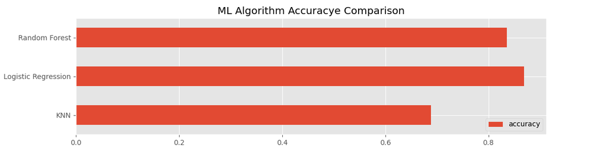

```python
#Model comparsion
model_compare = pd.DataFrame(model_scores, index=['accuracy'])
plt.style.use('ggplot')
model_compare.T.plot.barh(title='ML Algorithm Accuracye Comparison', figsize=(12,3))
%matplot plt
```

#### Hyperparameter tuning

Hyperparameter tunning will performed on only those algorithms with best model scores. In this experiment it will performed on LogisticRegression and RandomForestClassifier

- Tuning models with with RandomizedSearchCV : tries n_iter combinations of hyperparameters and saves the best.
- Tuning a model with GridSearchCV : tries every single combination of hyperparameters and saves the best.

To test different hyperparameters, one could use a validation set. Since the data used in this experiment ~300 records, we'll use cross-validation.  
The most common type of cross-validation is k-fold. It involves splitting data into k-fold's and then testing a model on each

```python
##------------------------------------------------------------------------------------
# Evaluate short listed algorithms for  hyperparameter tunning and transition the
# model/s to “staging” which meet the threshold
##------------------------------------------------------------------------------------

#set model threshold score
hypThreshold=float(0.88)

# Create hyperparameter dictionary
hyper_Dict = {1: {'ml-algorithm':'LogisticRegression', 'tunning-method':'RandomizedSearchCV'},
              2: {'ml-algorithm':'LogisticRegression', 'tunning-method':'GridSearchCV'},
              3: {'ml-algorithm':'RandomForest', 'tunning-method':'RandomizedSearchCV'}}

# create a hyperparameter grid (a dictionary of different hyperparameters) for each and then test them out.
log_reg_grid = {"C": np.logspace(-4, 4, 20), "solver": ["liblinear"]}

# Different RandomForestClassifier hyperparameters
rf_grid = {"n_estimators": np.arange(10, 1000, 50), "max_depth": [None, 3, 5, 10],
           "min_samples_split": np.arange(2, 20, 2), "min_samples_leaf": np.arange(1, 20, 2)}

# Create dataframe to store best hyperparamaters & score
LR_hyp = pd.DataFrame(columns=['ml-algorithm','tunning-method', 'best-parms', 'score'])

# Set random seed
np.random.seed(42)

# Set multiple tags at once
tags = {"reMark": "hyperparameter-tunning-cv",
        "runVersion": "1.0.0"}

# Set model stage status
stage = "Staging" # values for <stage>: Staging|Archived|Production|None

print("Started hyperparameter tunning on selected ml algorithms, this may take some time.....")
for name, hyper_Dict in hyper_Dict.items():
    #print("run-name:", hyper_Dict['ml-algorithm'])

    if hyper_Dict['ml-algorithm'] == 'LogisticRegression' and hyper_Dict['tunning-method'] == 'RandomizedSearchCV':
        #mlflow_run_name = hyper_Dict['ml-algorithm']+ '-' +hyper_Dict['tunning-method']
        mlflow_run_name = 'Hyperparameter-LR'+ '-' +hyper_Dict['tunning-method']
        with mlflow.start_run(run_name = mlflow_run_name) as run:
            mlflow.set_tags (tags) #set multiple tags at once
            # enable autologging
            mlflow.sklearn.autolog()
            # Setup random hyperparameter search for LogisticRegression
            rs_log_reg = RandomizedSearchCV(LogisticRegression(), param_distributions=log_reg_grid, cv=5, n_iter=20, verbose=True)
            # Fit random hyperparameter search model
            rs_log_reg.fit(X_train, y_train)
            # Log Models With Signatures
            signature = infer_signature(X_train, rs_log_reg.predict(X_train))
            best_parms = rs_log_reg.best_params_
            score = rs_log_reg.score(X_test, y_test)
            LR_hyp = LR_hyp.append({'ml-algorithm':hyper_Dict['ml-algorithm'], 'tunning-method':hyper_Dict['tunning-method'], 'best-parms':best_parms, 'score':score},ignore_index=True)

            # Register the model if it meets the threshold
            if float(score) >= hypThreshold:
                print(" Model met threshold and registred was :",  mlflow_run_name)
                reg_model_name = experiment_name + '-' + mlflow_run_name
                mlflow.sklearn.log_model(sk_model=name, artifact_path="model",registered_model_name=reg_model_name
                                         ,signature=signature)
                # Transition the current model to 'Staging'
                client = MlflowClient()
                # Get all versions of the model filtered by name
                model_name = reg_model_name
                filter_string = "name='{}'".format(model_name)
                results = client.search_model_versions(filter_string)
            for res in results:
                current_version = res.version
                desc = "This model is a version of scikit-learn" + model_name + ".This model met the threshold"
            client.transition_model_version_stage(name=model_name,stage=stage,version=current_version) #add/update stage & version
            client.update_model_version(name=model_name, version=current_version, description=desc) #add/update description
        mlflow.end_run()

    elif hyper_Dict['ml-algorithm'] == 'LogisticRegression' and hyper_Dict['tunning-method'] == 'GridSearchCV':
        #mlflow_run_name = hyper_Dict['ml-algorithm'] + '-' + hyper_Dict['tunning-method']
        mlflow_run_name = 'Hyperparameter-LR'+ '-' +hyper_Dict['tunning-method']
        with mlflow.start_run(run_name = mlflow_run_name) as run:
            mlflow.set_tags (tags) #set multiple tags at once
            # enable autologging
            mlflow.sklearn.autolog()
            # Setup random hyperparameter search for LogisticRegression
            gs_log_reg = GridSearchCV(LogisticRegression(), param_grid=log_reg_grid, cv=5, verbose=True)
            # Fit random hyperparameter search model
            gs_log_reg.fit(X_train, y_train)
            # Log Models With Signatures
            signature = infer_signature(X_train, gs_log_reg.predict(X_train))
            best_parms = gs_log_reg.best_params_
            score = gs_log_reg.score(X_test, y_test)
            LR_hyp = LR_hyp.append({'ml-algorithm':hyper_Dict['ml-algorithm'], 'tunning-method':hyper_Dict['tunning-method'], 'best-parms':best_parms, 'score':score},ignore_index=True)
            # Register the model if it meets the threshold
            if float(score) >= hypThreshold:
                print(" Model met threshold and registred was :",  mlflow_run_name)
                reg_model_name = experiment_name + '-' + mlflow_run_name
                mlflow.sklearn.log_model(sk_model=name, artifact_path="model",registered_model_name=reg_model_name
                                         ,signature=signature)
                # Transition the current model to 'Staging'
                client = MlflowClient()
                # Get all versions of the model filtered by name
                model_name = reg_model_name
                filter_string = "name='{}'".format(model_name)
                results = client.search_model_versions(filter_string)
            for res in results:
                current_version = res.version
                desc = "This model is a version of scikit-learn" + model_name + ".This model met the threshold"
            client.transition_model_version_stage(name=model_name,stage=stage,version=current_version) #add/update stage & version
            client.update_model_version(name=model_name, version=current_version, description=desc) #add/update description
        mlflow.end_run()

    elif hyper_Dict['ml-algorithm'] == 'RandomForest' and hyper_Dict['tunning-method'] == 'RandomizedSearchCV':
        #mlflow_run_name = hyper_Dict['ml-algorithm'] + '-' + hyper_Dict['tunning-method']
        mlflow_run_name = 'Hyperparameter-RF'+ '-' + hyper_Dict['tunning-method']
        with mlflow.start_run(run_name = mlflow_run_name) as run:
            mlflow.set_tags (tags) #set multiple tags at once
            # enable autologging
            mlflow.sklearn.autolog()
            # Setup random hyperparameter search for RandomForestClassifier
            rs_rf = RandomizedSearchCV(RandomForestClassifier(), param_distributions=rf_grid, cv=5, n_iter=20, verbose=True)
            # Fit random hyperparameter search model
            rs_rf.fit(X_train, y_train)
            # Log Models With Signatures
            signature = infer_signature(X_train, rs_rf.predict(X_train))
            # Find the best parameters
            best_parms = rs_rf.best_params_
            # Evaluate the randomized search random forest model
            score = rs_rf.score(X_test, y_test)
            LR_hyp = LR_hyp.append({'ml-algorithm':hyper_Dict['ml-algorithm'], 'tunning-method':hyper_Dict['tunning-method'], 'best-parms':best_parms, 'score':score},ignore_index=True)
            # Register the model if it meets the threshold
            if float(score) >= hypThreshold:
                print(" Model met threshold and registred was :",  mlflow_run_name)
                reg_model_name = experiment_name + '-' + mlflow_run_name
                mlflow.sklearn.log_model(sk_model=name, artifact_path="model", registered_model_name=reg_model_name
                                         ,signature=signature)
                # Transition the current model to 'Staging'
                client = MlflowClient()
                # Get all versions of the model filtered by name
                model_name = reg_model_name
                filter_string = "name='{}'".format(model_name)
                results = client.search_model_versions(filter_string)
            for res in results:
                current_version = res.version
                desc = "This model is a version of scikit-learn" + model_name + ".This model met the threshold"
            client.transition_model_version_stage(name=model_name,stage=stage,version=current_version) #add/update stage & version
            client.update_model_version(name=model_name, version=current_version, description=desc) #add/update description
        mlflow.end_run()

print("-----------------------------------------------------------------------------------")
print('finished hyperparameter tunning, check hyperparameter scoring dataframe and mlflow to compare ml-models/algorithms')
```

```
Started hyperparameter tunning on selected ml algorithms, this may take some time.....
Fitting 5 folds for each of 20 candidates, totalling 100 fits
 Model met threshold and registred was : Hyperparameter-LR-RandomizedSearchCV
Fitting 5 folds for each of 20 candidates, totalling 100 fits
 Model met threshold and registred was : Hyperparameter-LR-GridSearchCV
Fitting 5 folds for each of 20 candidates, totalling 100 fits
-----------------------------------------------------------------------------------
finished hyperparameter tunning, check hyperparameter scoring dataframe and mlflow to compare ml-models/algorithms
```

```python
from tabulate import tabulate
# Set it to None to display all columns in the dataframe
pd.set_option('display.width', None)
print("Hyperparameter Tunning details: ", LR_hyp, sep='\n')
```

```
Hyperparameter Tunning details:
         ml-algorithm      tunning-method                                         best-parms     score
0  LogisticRegression  RandomizedSearchCV  {'solver': 'liblinear', 'C': 0.23357214690901212}  0.885246
1  LogisticRegression        GridSearchCV  {'C': 0.23357214690901212, 'solver': 'liblinear'}  0.885246
2        RandomForest  RandomizedSearchCV  {'n_estimators': 110, 'min_samples_split': 2, ...  0.868852
```

#### Track ML model Hyperparameter tunning and registered best models

[figure not shown]

#### mlflow UI - Compare model metrics

[figure not shown]

#### Evaluating a classification model for best the ML algorithm

From above we can see that both the tunning method RandomizedSearchCV and GridSearchCV on LogisticRegression have same score when compared with RandomForest  
Now have narrow down to best ML algorithm and its hypermeter tunning methods, we can now continue to evaluate the best model on following metrics on **single training** and **test set**.

- ROC curve and AUC score - plot_roc_curve()
- Confusion matrix - confusion_matrix()
- Classification report - classification_report()
- Precision - precision_score()
- Recall - recall_score()
- F1-score - f1_score()

```python
##-------------------------------------------------------------------------------------------
# Evaluate best algorithms with and without hyperparameter against cross-validation
# single-training-test data and transition the model/s to “staging” which meet the threshold
##-------------------------------------------------------------------------------------------

#set model metrics threshold
accThreshold=float(0.85)
precThreshold=float(0.87)
recallThreshold=float(0.87)
f1Threshold=float(0.87)

# instantiate the model
logreg = LogisticRegression(max_iter=1000)

# Set random seed
np.random.seed(42)

from sklearn.metrics import accuracy_score
# Create ml-algorithm dictionary for final model

hyper_eval = {1: {'ml-algorithm':'LR-without-HyperParams', 'set': 'single-training-test'},
              2: {'ml-algorithm':'LR-GS-HyperParams-CV', 'set': 'cross-validation'}}

# Create dataframe to store model metrics
mdl_metrics = pd.DataFrame(columns=['ml-algorithm','Accuracy', 'Precision', 'Recall', 'F1'])

# Set model stage status
stage = "Production" # values for <stage>: Staging|Archived|Production|None

for name, hyper_eval in hyper_eval.items():
    if hyper_eval['set'] == 'single-training-test':
        mlflow_run_name = hyper_eval['ml-algorithm']
        tags = {"reMark": "no hyper params", "runVersion": "1.0.0"}
        with mlflow.start_run(run_name = mlflow_run_name) as run:
            mlflow.set_tags (tags) #set multiple tags at once
            mlflow.sklearn.autolog()
            logreg = LogisticRegression(max_iter=1000)
            logreg.fit(X_train,y_train)
            # Make preidctions on test data
            y_preds = logreg.predict(X_test)
            accuracy = accuracy_score(y_test, y_preds)
            precision = precision_score(y_test, y_preds)
            recall = recall_score(y_test, y_preds)
            f1= f1_score(y_test, y_preds)

            # Log Models With Signatures
            signature = infer_signature(X_train, logreg.predict(X_train))

            singleSet_metrics = pd.DataFrame({"Accuracy": accuracy, "Precision": precision,
                                        "Recall": recall, "F1": f1}, index=[0])
            mdl_metrics = mdl_metrics.append({'ml-algorithm':hyper_eval['ml-algorithm'], 'Accuracy':accuracy, 'Precision':precision, 'Recall':recall, 'F1':f1},ignore_index=True)
            # Register the model if it meets the threshold
            if (float(accuracy) >= accThreshold) and (float(precision) >= precThreshold) and (float(f1) >= f1Threshold) and (float(recall) >= recallThreshold):
                print(" Model met threshold and registred was :",  mlflow_run_name)
                reg_model_name = experiment_name + '-' + mlflow_run_name
                # Register the model
                mlflow.sklearn.log_model(sk_model=logreg, artifact_path="model", registered_model_name=reg_model_name
                                         , signature=signature)
                # Transition the current model to 'Production'
                client = MlflowClient()
                # Get all versions of the model filtered by name
                model_name = reg_model_name
                filter_string = "name='{}'".format(model_name)
                results = client.search_model_versions(filter_string)
                for res in results:
                    current_version = res.version
                    desc = "This model is a version of scikit-learn" + model_name + ".This model met the threshold"
                    client.transition_model_version_stage(name=model_name,stage=stage,version=current_version) #stage & version
                    client.update_model_version(name=model_name, version=current_version, description=desc) #add/update description
        mlflow.end_run()
    elif hyper_eval['set'] == 'cross-validation':
        mlflow_run_name = hyper_eval['ml-algorithm']
        tags = {"reMark": "with best hyper params", "runVersion": "1.0.0"}
        with mlflow.start_run(run_name = mlflow_run_name) as run:
            mlflow.set_tags (tags) #set multiple tags at once
            mlflow.sklearn.autolog()
            # Import cross_val_score
            from sklearn.model_selection import cross_val_score
            # Instantiate best model with best hyperparameters (found with GridSearchCV)
            clf = LogisticRegression(C=0.23357214690901212, solver="liblinear")
            # Cross-validated accuracy score
            cv_acc = cross_val_score(clf, X, y,cv=5, scoring="accuracy")
            cv_acc = np.mean(cv_acc)
            # Cross-validated precision score
            cv_precision = np.mean(cross_val_score(clf, X, y, cv=5, scoring="precision"))
            # Cross-validated recall score
            cv_recall = np.mean(cross_val_score(clf, X, y, cv=5, scoring="recall"))
            # Cross-validated F1 score
            cv_f1 = np.mean(cross_val_score(clf,X, y, cv=5, scoring="f1"))
            cv_metrics = pd.DataFrame({"Accuracy": cv_acc, "Precision": cv_precision,
                                        "Recall": cv_recall, "F1": cv_f1}, index=[0])
            # Log Models With Signatures
            signature = infer_signature(cross_val_predict(clf, X, y, cv=5))
            mdl_metrics = mdl_metrics.append({'ml-algorithm':hyper_eval['ml-algorithm'], 'Accuracy':cv_acc, 'Precision':cv_precision, 'Recall':cv_recall, 'F1':cv_f1},ignore_index=True)
            # Fit an instance of LogisticRegression (taken from above)
            clf.fit(X_train, y_train)
            # Register the model if it meets the threshold
            if (float(cv_acc) >= accThreshold) and (float(cv_precision) >= precThreshold) and (float(cv_f1) >= f1Threshold) and (float(cv_recall) >= recallThreshold):
                print(" Model met threshold and registred was :", mlflow_run_name)
                reg_model_name = experiment_name + '-' + mlflow_run_name
                # Register the model
                mlflow.sklearn.log_model(sk_model=clf, artifact_path="model", registered_model_name=reg_model_name
                                         , signature=signature)
                #mlflow.sklearn.log_model(sk_model=name, artifact_path="model", registered_model_name=reg_model_name)
                # Transition the current model to 'Production'
                client = MlflowClient()
                # Get all versions of the model filtered by name
                model_name = reg_model_name
                filter_string = "name='{}'".format(model_name)
                results = client.search_model_versions(filter_string)
                for res in results:
                    current_version = res.version
                    desc = "This model is a version of scikit-learn" + model_name + ".This model met the threshold"
                    client.transition_model_version_stage(name=model_name,stage=stage,version=current_version) #stage & version
                    client.update_model_version(name=model_name, version=current_version, description=desc) #add/update description
        mlflow.end_run()
```

```
 Model met threshold and registred was : LR-without-HyperParams
```

```python
print(tabulate(mdl_metrics, headers='keys', tablefmt='psql'))
```

```
+----+------------------------+------------+-------------+----------+---------+
|    | ml-algorithm           |   Accuracy |   Precision |   Recall |      F1 |
|----+------------------------+------------+-------------+----------+---------|
|  0 | LR-without-HyperParams |   0.868852 |    0.875    | 0.875    | 0.875   |
|  1 | LR-GS-HyperParams-CV   |   0.847978 |    0.821587 | 0.927273 | 0.87054 |
+----+------------------------+------------+-------------+----------+---------+
```

- **Precision -** Indicates the proportion of positive identifications (model predicted class 1) which were actually correct. A model which produces no false positives has a precision of 1.0.
- **Recall -** Indicates the proportion of actual positives which were correctly classified. A model which produces no false negatives has a recall of 1.0.
- **F1 score - A** combination of precision and recall. A perfect model achieves an F1 score of 1.0.
- **Accuracy -** The accuracy of the model in decimal form. Perfect accuracy is equal to 1.0.

#### mlflow UI - Tracking ML models, registering the shortlisted model and transition to “Production” stage

[figure not shown]

#### Feature Importance overview

##### Which features contributing most to the outcomes of the model?

The larger the value (bigger bar), the more the feature contributes to the models decision.  
If the value is negative, it means there's a negative correlation. And vice versa for positive values.

[figure not shown]

```python
# Visualizing cross-validated metrics
plt.style.use('ggplot')
singleSet_metrics = pd.DataFrame({"Accuracy": cv_acc,
                            "Precision": cv_precision,
                            "Recall": cv_recall,
                            "F1": cv_f1},
                          index=[0])

cv_metrics.T.plot.barh(title="Logistic regression without Hyperparmaeters", legend=False, figsize=(10, 3))
%matplot plt
```

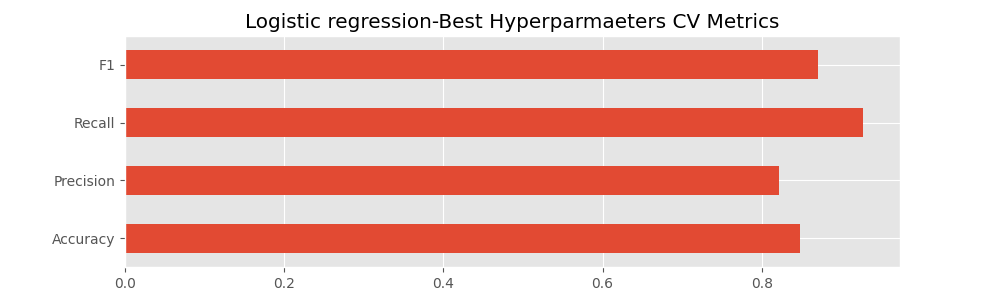

```python
# Visualizing cross-validated metrics
plt.style.use('ggplot')
cv_metrics = pd.DataFrame({"Accuracy": cv_acc,
                            "Precision": cv_precision,
                            "Recall": cv_recall,
                            "F1": cv_f1},
                          index=[0])

cv_metrics.T.plot.barh(title="Logistic regression-Best Hyperparmaeters CV Metrics", legend=False, figsize=(10, 3))
%matplot plt
```

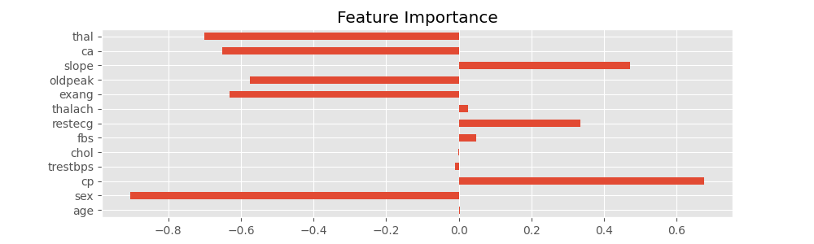

```python
# Match features to columns
features_dict = dict(zip(heart_df.columns, list(clf.coef_[0])))
# Visualize feature importance
plt.style.use('ggplot')
features_df = pd.DataFrame(features_dict, index=[0])
features_df.T.plot.barh(title="Feature Importance", legend=False, figsize=(10,3))
%matplot plt
```

#### Feature Importance overview

##### Which features contributing most to the outcomes of the model?

The larger the value (bigger bar), the more the feature contributes to the models decision.  
If the value is negative, it means there's a negative correlation. And vice versa for positive values.

#### mlflow UI - Model Artifacts

[figure not shown]

#### Conclusion

Note: Ideally 95% of accuracy would have been optimal score for model to be productionised

```python
# Transit non-production models (i.e. model with status as "Staging") to stage=Archived
client = MlflowClient()
for rm in client.list_registered_models():
    d1 = dict(rm)
    reg_model_name = d1['name']
    model_name = reg_model_name
    s = d1['latest_versions']
    lv_str =  ' '.join(map(str,s)) #convert list to string
    start = lv_str.find('current_stage=') + 14
    end = lv_str.find(', description', start)
    stg_name = lv_str[start:end]
    #print('Model Name :', reg_name, 'stage name :',stg_name)
    filter_string = "name='{}'".format(model_name) #set filter
    results = client.search_model_versions(filter_string)
    for res in results:
        current_version = res.version
        # checking id the model is staging or production
        if stg_name == "'Staging'":
            trnst_name = 'Archived'
            print('Model Name :', reg_model_name, 'Changed Stage status from :', stg_name, 'to' ,trnst_name)
            client.transition_model_version_stage(name=model_name,stage=trnst_name,version=current_version)
```

```
Model Name : Predict-Heart-Disease-Hyperparameter-LR-GridSearchCV Changed Stage status from : 'Staging' to Archived
Model Name : Predict-Heart-Disease-Logistic Regression Changed Stage status from : 'Staging' to Archived
Model Name : Predict-Heart-Disease-Random Forest Changed Stage status from : 'Staging' to Archived
```

#### mlflow UI - Archiving ML models (transition models staging to archived)

[figure not shown]

#### Predict if patient has heart disease on production data

The application loads the latest version of the model from the specified stage and uses to predict if the patient has heart disease on the production data (i.e. data not used for train or testing the model)

```python
prod_data = pd.read_csv("https://raw.githubusercontent.com/npkum/mlops/gh-pages/data/prod-heart-disease.csv") # 'DataFrame' shortened to 'df'
prod_data = prod_data.astype(float)

#  Fetch an MLflow model from the Model Registry and predict on a pandas/spark DataFrame
client = MlflowClient()
for rm in client.list_registered_models():
    d1 = dict(rm)
    reg_model_name = d1['name']
    s = d1['latest_versions']
    lv_str =  ' '.join(map(str,s)) #convert list to string
    start = lv_str.find('current_stage=') + 14
    end = lv_str.find(', description', start)
    stg_name = lv_str[start:end]
    if stg_name == "'Production'":
        filter_string = "name='{}'".format(reg_model_name) #set filter
        results = client.search_model_versions(filter_string)
        current_version = max(res.version)
        stg_status = stg_name.strip("'")
        print('----------------------------------------------------------------------------------------------')
        print('Model Name :', reg_model_name, 'Stage Name :', stg_status, 'Version :', current_version)
        print('----------------------------------------------------------------------------------------------')
        # Load model as a PyFuncModel.
        model = mlflow.pyfunc.load_model(model_uri=f"models:/{reg_model_name}/{stg_status}")

        # Predict on a Pandas DataFrame
        prod_data['target'] = model.predict(prod_data)

# display predicted values on prod data
prod_data
```

```
----------------------------------------------------------------------------------------------
Model Name : Predict-Heart-Disease-LR-without-HyperParams Stage Name : Production Version : 1
----------------------------------------------------------------------------------------------
    age  sex   cp  trestbps   chol  fbs  restecg  thalach  exang  oldpeak  slope   ca  thal  target
0  75.0  1.0  3.0     125.0  233.0  1.0      0.0    150.0    0.0      2.3    0.0  0.0   1.0     1.0
1  39.0  1.0  2.0     130.0  250.0  0.0      1.0    187.0    0.0      3.5    0.0  0.0   2.0     1.0
2  41.0  0.0  1.0     130.0  204.0  0.0      0.0    172.0    0.0      1.4    2.0  0.0   2.0     1.0
3  58.0  1.0  1.0     120.0  236.0  0.0      1.0    178.0    0.0      0.8    2.0  0.0   2.0     1.0
4  59.0  0.0  0.0     120.0  354.0  0.0      1.0    163.0    1.0      0.6    2.0  0.0   2.0     1.0
5  56.0  1.0  0.0     125.0  249.0  1.0      0.0    144.0    1.0      1.2    1.0  1.0   2.0     0.0
6  56.0  1.0  2.0     130.0  256.0  1.0      0.0    142.0    1.0      0.6    1.0  1.0   1.0     1.0
```

```python
# house-keeping
# Delete a registered model along with all its versions
client = MlflowClient()
client.delete_registered_model(name="Predict-Heart-Disease-Random Forest")
#client.delete_model_version(name="Predict-Heart-Disease-Logistic Regression", version=2)
```

#### How mlflow Runs and Artifacts are Recorded

[figure not shown]

Created by: [Kumar N.P](https://www.linkedin.com/in/kumar-np)